# An introduction to phylogenetic comparative methods in R

This tutorial is intended to get you familiar with the R environment for conducting phylogenetic comparative analyses.

## I. Preparing the R environment

### Installing packages

To install a package directly from CRAN, use:

```r
install.packages("geiger")
```

Load the package using ‘library’

```r
library(geiger)
```

These days, many packages may not be on CRAN, but instead hosted on github, bitbucket etc. To install these packages, it’s useful to use the `devtools` package:

```r
install_github("richfitz/sowsear")
install_github("arborworkflows/aRbor")
```

```r
library(sowsear)
library(devtools)
library(aRbor)
```

For phylogenetic comparative methods, there are a number of packages available. One place to find them all is the ‘Phylogenetics Task View’ run by Brian O’meara: (http://cran.r-project.org/web/views/Phylogenetics.html) All of these packages can be installed at once using the following lines (however, please note that this process can take a considerable amount of time)

```r
install.packages("ctv")
install.views("Phylogenetics")
```

### Directory management

R looks for files in the ‘working directory’.

```r
getwd()
```

```
## [1] "/home/josef/repos/SSBphylogenetics/R"
```

```r
dir.create("~/repos/SSBphylogenetics")
dir.create("~/repos/SSBphylogenetics/R")
dir.create("~/repos/SSBphylogenetics/data")
dir.create("~/repos/SSBphylogenetics/output")
```

```r
setwd("~/repos/SSBphylogenetics/R/")
```

Save this script into the folder ‘./R’ and place your data files into the directory ‘./data’ Now we are ready to read in data and tree files.

### II. Reading in a tree & tree data structures

There are a number of functions to read in phylogenetic tree data into R. We are going to use as our example tree phylogeny of Muroid rodents (Schenk, Rowe & Steppan, 2013; Systematic Biology). The tree can be downloaded from my github site, or it be accessed directly from treebase (submission 12303).

```r
tree <- read.tree("../data/schenk.tre")
tree
```

```
##
## Phylogenetic tree with 305 tips and 304 internal nodes.
##
## Tip labels:
##  Eliomys_quercinus, Sciurus_sp., Sicista_tianshanica, Napaeozapus_insignis, Zapus_princeps, Allactaga_sibirica, ...
##
## Rooted; includes branch lengths.
```

We can plot the tree:

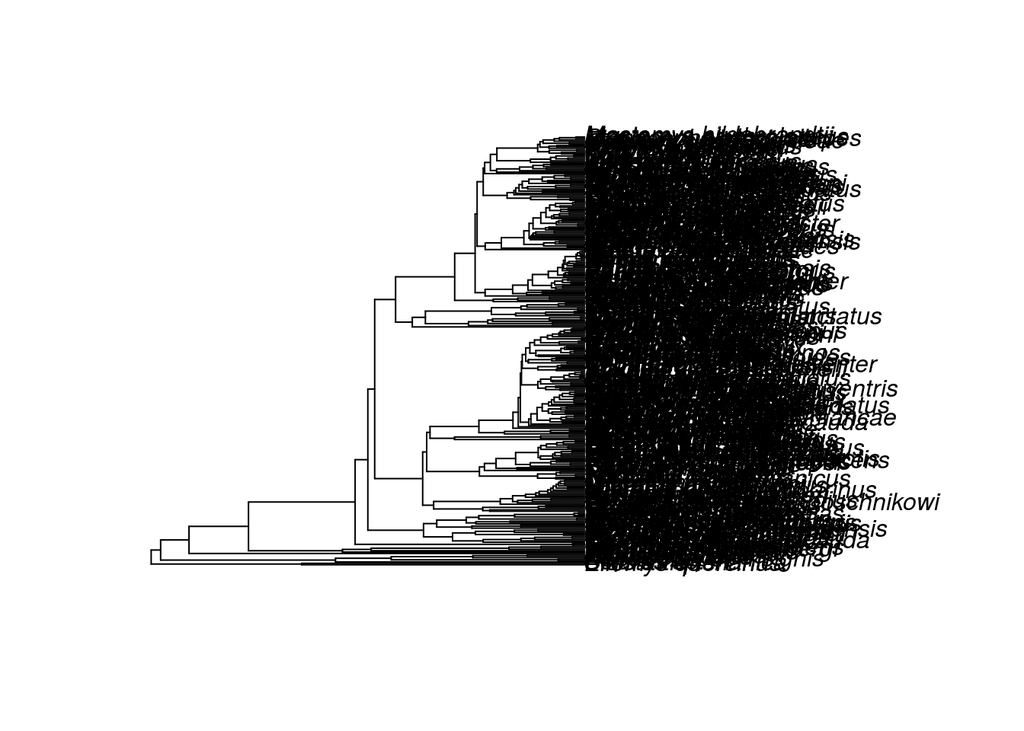

```r
plot(tree)
```

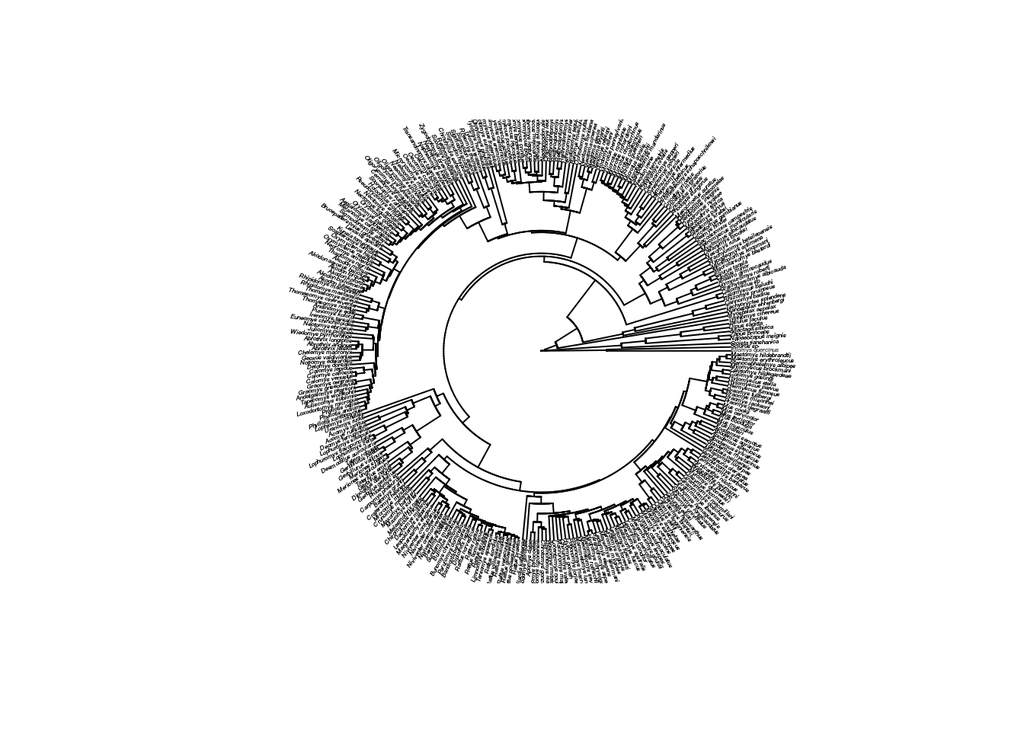

```r
plot(tree, type="fan", cex=0.25)
```

You may notice that the help file for `plot` is not very helpful for options for phylogenies:

```r
?plot
```

This is because `plot` is a “method” that behaves differently on objects of different classes.

```r
plot
```

```
## function (x, y, ...)
## UseMethod("plot")
## <bytecode: 0x17cfe48>
## <environment: namespace:graphics>
```

```r
methods(plot)
```

```
##  [1] plot.aareg*           plot.acf*             plot.ACF*
##  [4] plot.agnes*           plot.anosim*          plot.asrArbor*
##  [7] plot.augPred*         plot.auteurMCMC*      plot.auteurMCMCMC*
## [10] plot.backbonePhylo*   plot.betadisper*      plot.betadiver*
## [13] plot.cascadeKM*       plot.cca*             plot.clade.tree*
## [16] plot.clamtest*        plot.clusGap*         plot.cohesiveBlocks*
## [19] plot.compareFits*     plot.contMap*         plot.contribdiv*
## [22] plot.correlogram      plot.correlogramList  plot.correspondence*
## [25] plot.cox.zph*         plot.data.frame*      plot.decomposed.ts*
## [28] plot.decorana*        plot.default          plot.dendrite*
## [31] plot.dendrogram*      plot.density*         plot.densityMap*
## [34] plot.describe.simmap* plot.deSolve*         plot.diana*
## [37] plot.dtlik.t*         plot.ecdf             plot.envfit*
## [40] plot.evonet           plot.factor*          plot.fisher*
## [43] plot.fisherfit*       plot.fitspecaccum*    plot.formula*
## [46] plot.function         plot.gam*             plot.gls*
## [49] plot.hclust*          plot.histogram*
##  [ reached getOption("max.print") -- omitted 94 entries ]
## see '?methods' for accessing help and source code
```

```r
class(tree)
```

```
## [1] "phylo"
```

```r
?plot.phylo
```

How is a tree stored? How can it be manipulated and modified? A tree object in R is a data structure called a “list”, and given a species class, called a “phylo” object. It will be worth your time getting familiar with [data structures in R](http://adv-r.had.co.nz/Data-structures.html).

`str` is a useful commands for determining what is in an R object:

```r
str(tree)
```

```
## List of 4
##  $ edge       : int [1:608, 1:2] 306 307 307 306 308 309 309 310 311 311 ...
##  $ Nnode      : int 304
##  $ tip.label  : chr [1:305] "Eliomys_quercinus" "Sciurus_sp." "Sicista_tianshanica" "Napaeozapus_insignis" ...
##  $ edge.length: num [1:608] 16.45 30.95 30.95 1.04 19.12 ...
##  - attr(*, "class")= chr "phylo"
##  - attr(*, "order")= chr "cladewise"
```

Each element of the list can be accessed by multiple means:

```r
tree['tip.label']
```

```
## $tip.label
##  [1] "Eliomys_quercinus"            "Sciurus_sp."
##  [3] "Sicista_tianshanica"          "Napaeozapus_insignis"
##  [5] "Zapus_princeps"               "Allactaga_sibirica"
##  [7] "Dipus_sagitta"                "Jaculus_jaculus"
##  [9] "Typhlomys_cinereus"           "Myospalax_aspalax"
## [11] "Nanospalax_ehrenbergi"        "Tachyoryctes_splendens"
## [13] "Cannomys_badius"              "Rhizomys_pruinosus"
## [15] "Calomyscus_baluchi"           "Calomyscus_sp"
## [17] "Brachytarsomys_albicauda"     "Gymnuromys_roberti"
## [19] "Voalavo_gymnocaudus"          "Eliurus_minor"
## [21] "Eliurus_tanala"               "Macrotarsomys_bastardi"
## [23] "Monticolomys_koopmani"        "Hypogeomys_antimena"
## [25] "Brachyuromys_betsileoensis"   "Nesomys_rufus"
## [27] "Delanymys_brooksi"            "Mystromys_albicaudatus"
## [29] "Petromyscus_monticularis"     "Saccostomus_campestris"
## [31] "Beamys_hindei"                "Cricetomys_gambianus"
## [33] "Steatomys_krebsi"             "Steatomys_parvus"
## [35] "Malacothrix_typica"           "Dendromus_nyasae"
## [37] "Dendromus_insignis"           "Dendromus_mesomelas"
## [39] "Mesocricetus_auratus"         "Phodopus_sungorus"
## [41] "Cricetulus_griseus"           "Cricetulus_migratorius"
## [43] "Cricetus_cricetus"            "Prometheomys_schaposchnikowi"
## [45] "Ondatra_zibethicus"           "Phenacomys_intermedius"
## [47] "Lemmus_sibiricus"             "Synaptomys_cooperi"
## [49] "Clethrionomys_gapperi"        "Chionomys_nivalis"
##  [ reached getOption("max.print") -- omitted 255 entries ]
```

```r
tree[['tip.label']]
```

```
##  [1] "Eliomys_quercinus"            "Sciurus_sp."
##  [3] "Sicista_tianshanica"          "Napaeozapus_insignis"
##  [5] "Zapus_princeps"               "Allactaga_sibirica"
##  [7] "Dipus_sagitta"                "Jaculus_jaculus"
##  [9] "Typhlomys_cinereus"           "Myospalax_aspalax"
## [11] "Nanospalax_ehrenbergi"        "Tachyoryctes_splendens"
## [13] "Cannomys_badius"              "Rhizomys_pruinosus"
## [15] "Calomyscus_baluchi"           "Calomyscus_sp"
## [17] "Brachytarsomys_albicauda"     "Gymnuromys_roberti"
## [19] "Voalavo_gymnocaudus"          "Eliurus_minor"
## [21] "Eliurus_tanala"               "Macrotarsomys_bastardi"
## [23] "Monticolomys_koopmani"        "Hypogeomys_antimena"
## [25] "Brachyuromys_betsileoensis"   "Nesomys_rufus"
## [27] "Delanymys_brooksi"            "Mystromys_albicaudatus"
## [29] "Petromyscus_monticularis"     "Saccostomus_campestris"
## [31] "Beamys_hindei"                "Cricetomys_gambianus"
## [33] "Steatomys_krebsi"             "Steatomys_parvus"
## [35] "Malacothrix_typica"           "Dendromus_nyasae"
## [37] "Dendromus_insignis"           "Dendromus_mesomelas"
## [39] "Mesocricetus_auratus"         "Phodopus_sungorus"
## [41] "Cricetulus_griseus"           "Cricetulus_migratorius"
## [43] "Cricetus_cricetus"            "Prometheomys_schaposchnikowi"
## [45] "Ondatra_zibethicus"           "Phenacomys_intermedius"
## [47] "Lemmus_sibiricus"             "Synaptomys_cooperi"
## [49] "Clethrionomys_gapperi"        "Chionomys_nivalis"
##  [ reached getOption("max.print") -- omitted 255 entries ]
```

```r
tree[[3]]
```

```
##  [1] "Eliomys_quercinus"            "Sciurus_sp."
##  [3] "Sicista_tianshanica"          "Napaeozapus_insignis"
##  [5] "Zapus_princeps"               "Allactaga_sibirica"
##  [7] "Dipus_sagitta"                "Jaculus_jaculus"
##  [9] "Typhlomys_cinereus"           "Myospalax_aspalax"
## [11] "Nanospalax_ehrenbergi"        "Tachyoryctes_splendens"
## [13] "Cannomys_badius"              "Rhizomys_pruinosus"
## [15] "Calomyscus_baluchi"           "Calomyscus_sp"
## [17] "Brachytarsomys_albicauda"     "Gymnuromys_roberti"
## [19] "Voalavo_gymnocaudus"          "Eliurus_minor"
## [21] "Eliurus_tanala"               "Macrotarsomys_bastardi"
## [23] "Monticolomys_koopmani"        "Hypogeomys_antimena"
## [25] "Brachyuromys_betsileoensis"   "Nesomys_rufus"
## [27] "Delanymys_brooksi"            "Mystromys_albicaudatus"
## [29] "Petromyscus_monticularis"     "Saccostomus_campestris"
## [31] "Beamys_hindei"                "Cricetomys_gambianus"
## [33] "Steatomys_krebsi"             "Steatomys_parvus"
## [35] "Malacothrix_typica"           "Dendromus_nyasae"
## [37] "Dendromus_insignis"           "Dendromus_mesomelas"
## [39] "Mesocricetus_auratus"         "Phodopus_sungorus"
## [41] "Cricetulus_griseus"           "Cricetulus_migratorius"
## [43] "Cricetus_cricetus"            "Prometheomys_schaposchnikowi"
## [45] "Ondatra_zibethicus"           "Phenacomys_intermedius"
## [47] "Lemmus_sibiricus"             "Synaptomys_cooperi"
## [49] "Clethrionomys_gapperi"        "Chionomys_nivalis"
##  [ reached getOption("max.print") -- omitted 255 entries ]
```

```r
tree$tip.label
```

```
##  [1] "Eliomys_quercinus"            "Sciurus_sp."
##  [3] "Sicista_tianshanica"          "Napaeozapus_insignis"
##  [5] "Zapus_princeps"               "Allactaga_sibirica"
##  [7] "Dipus_sagitta"                "Jaculus_jaculus"
##  [9] "Typhlomys_cinereus"           "Myospalax_aspalax"
## [11] "Nanospalax_ehrenbergi"        "Tachyoryctes_splendens"
## [13] "Cannomys_badius"              "Rhizomys_pruinosus"
## [15] "Calomyscus_baluchi"           "Calomyscus_sp"
## [17] "Brachytarsomys_albicauda"     "Gymnuromys_roberti"
## [19] "Voalavo_gymnocaudus"          "Eliurus_minor"
## [21] "Eliurus_tanala"               "Macrotarsomys_bastardi"
## [23] "Monticolomys_koopmani"        "Hypogeomys_antimena"
## [25] "Brachyuromys_betsileoensis"   "Nesomys_rufus"
## [27] "Delanymys_brooksi"            "Mystromys_albicaudatus"
## [29] "Petromyscus_monticularis"     "Saccostomus_campestris"
## [31] "Beamys_hindei"                "Cricetomys_gambianus"
## [33] "Steatomys_krebsi"             "Steatomys_parvus"
## [35] "Malacothrix_typica"           "Dendromus_nyasae"
## [37] "Dendromus_insignis"           "Dendromus_mesomelas"
## [39] "Mesocricetus_auratus"         "Phodopus_sungorus"
## [41] "Cricetulus_griseus"           "Cricetulus_migratorius"
## [43] "Cricetus_cricetus"            "Prometheomys_schaposchnikowi"
## [45] "Ondatra_zibethicus"           "Phenacomys_intermedius"
## [47] "Lemmus_sibiricus"             "Synaptomys_cooperi"
## [49] "Clethrionomys_gapperi"        "Chionomys_nivalis"
##  [ reached getOption("max.print") -- omitted 255 entries ]
```

The structure of the tree is stored in the edge matrix:

```r
tree$edge
```

```
##        [,1] [,2]
##   [1,]  306  307
##   [2,]  307    1
##   [3,]  307    2
##   [4,]  306  308
##   [5,]  308  309
##   [6,]  309    3
##   [7,]  309  310
##   [8,]  310  311
##   [9,]  311    4
##  [10,]  311    5
##  [11,]  310  312
##  [12,]  312    6
##  [13,]  312  313
##  [14,]  313    7
##  [15,]  313    8
##  [16,]  308  314
##  [17,]  314    9
##  [18,]  314  315
##  [19,]  315  316
##  [20,]  316   10
##  [21,]  316  317
##  [22,]  317   11
##  [23,]  317  318
##  [24,]  318   12
##  [25,]  318  319
##  [ reached getOption("max.print") -- omitted 583 rows ]
```

And branch lengths are stored in the list element `edge.length`

```r
tree$edge.length
```

```
##  [1] 16.454920 30.951218 30.951218  1.036558 19.122934 27.246646  6.098144
##  [8] 18.255843  2.892659  2.892659  8.926983 12.221519  5.945134  6.276385
## [15]  6.276385  3.101443 43.268137  6.507266 10.276527 26.484344  3.141303
## [22] 23.343042 15.076585  8.266457  3.502364  4.764093  4.764093 11.663253
## [29] 23.784354  1.313264  1.313264  1.392402  6.091229  3.173725  3.347564
## [36] 11.092697  4.133406  6.959292  1.505509  5.453783  4.094128  1.359655
## [43]  1.359655  2.496259  9.647273  2.296729  2.296729  4.258825  7.685177
## [50]  2.595582
##  [ reached getOption("max.print") -- omitted 558 entries ]
```

Tips can be dropped with the function `drop.tip`:

```r
#tree before:
tree
```

```
##
## Phylogenetic tree with 305 tips and 304 internal nodes.
##
## Tip labels:
##  Eliomys_quercinus, Sciurus_sp., Sicista_tianshanica, Napaeozapus_insignis, Zapus_princeps, Allactaga_sibirica, ...
##
## Rooted; includes branch lengths.
```

```r
#tree after dropping two species:
drop.tip(tree, c("Eliomys_quercinus", "Sicista_tianshanica"))
```

```
##
## Phylogenetic tree with 303 tips and 302 internal nodes.
##
## Tip labels:
##  Sciurus_sp., Napaeozapus_insignis, Zapus_princeps, Allactaga_sibirica, Dipus_sagitta, Jaculus_jaculus, ...
##
## Rooted; includes branch lengths.
```

We can get a distance matrix from the tree as follows:

```r
dist <- cophenetic(tree)
dist[1:5,1:5]
```

```
##                      Eliomys_quercinus Sciurus_sp. Sicista_tianshanica
## Eliomys_quercinus              0.00000    61.90244            94.81228
## Sciurus_sp.                   61.90244     0.00000            94.81228
## Sicista_tianshanica           94.81228    94.81228             0.00000
## Napaeozapus_insignis          94.81228    94.81228            54.49329
## Zapus_princeps                94.81228    94.81228            54.49329
##                      Napaeozapus_insignis Zapus_princeps
## Eliomys_quercinus               94.812276      94.812276
## Sciurus_sp.                     94.812276      94.812276
## Sicista_tianshanica             54.493291      54.493291
## Napaeozapus_insignis             0.000000       5.785318
## Zapus_princeps                   5.785318       0.000000
```

### III. Matching a tree with a dataset

```r
pantheria <- read.table("http://www.esapubs.org/archive/ecol/E090/184/PanTHERIA_1-0_WR05_Aug2008.txt",header=TRUE,sep="\t")
rownames(pantheria) <- gsub(" ", "_", pantheria$MSW05_Binomial)
head(pantheria)
```

[output not shown]

```r
td <- treedata(tree, pantheria)
```

[output not shown]

[output cut: 352 more lines]

[output not shown]

```r
td$data <- as.data.frame(td$data)
```

This part is a bit experimental, so forgive me if it causes problems. It utilizes the dplyr package, which is a powerful package for manipulating data frames written by Hadley Wickham. The aRbor package simply wraps the functions from dplyr into versions that work on a list with a tree and data frame, so that the tree and data frame always match each other.

```r
td <- make.treedata(tree, pantheria)
td$dat[td$dat==-999] <- NA
td <- mutate(td, lnMass = log(X5.1_AdultBodyMass_g), lnBMR= log(X5.2_BasalMetRateMass_g), lifespan=X17.1_MaxLongevity_m, desert=ifelse(X28.1_Precip_Mean_mm < 21, 1, 0))
td <- select(td, lnMass, lnBMR, lifespan, desert)
td <- filter(td, !is.na(lnMass), !is.na(lnBMR), !is.na(lifespan), !is.na(desert))

tree <- td$phy
dat <- td$dat
```

## IV. Visualization

Ape plotting:

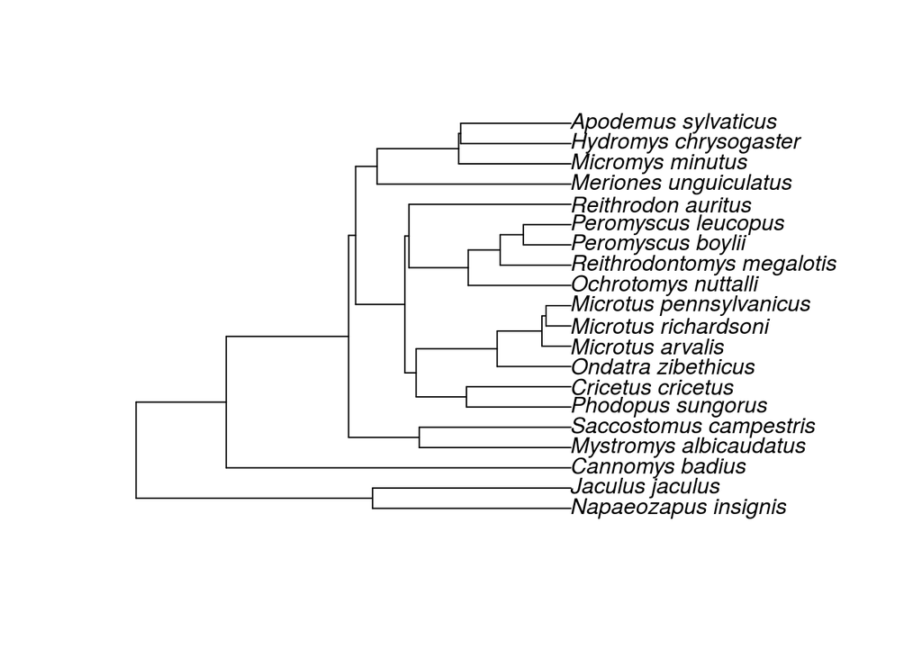

```r
plot(tree)
```

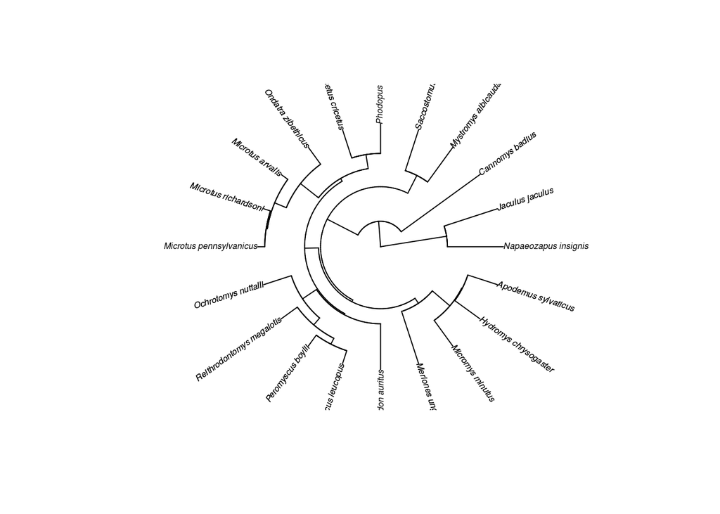

```r
plot(tree, type="fan", cex=0.5)
```

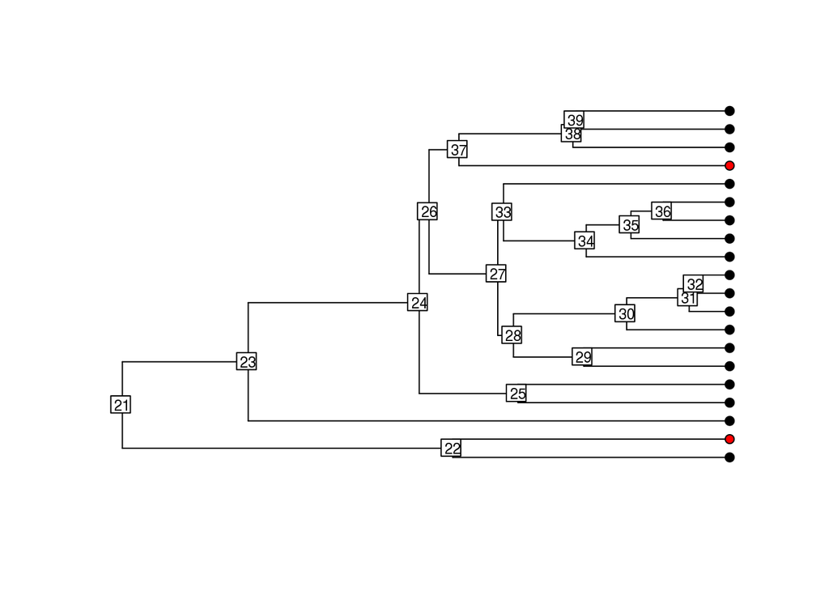

```r
plot(tree, show.tip.label=FALSE)
tiplabels(pch=21, bg=factor(dat$desert))
nodelabels(cex=0.75,bg="white" )
```

Plot a traitgram to visualize a continuous trait:

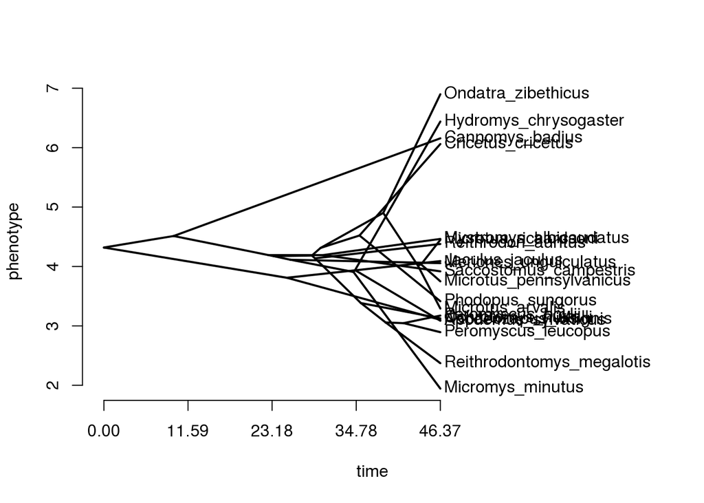

```r
require(phytools)
phenogram(tree, setNames(dat$lnMass, tree$tip.label), spread.labels=FALSE)
```

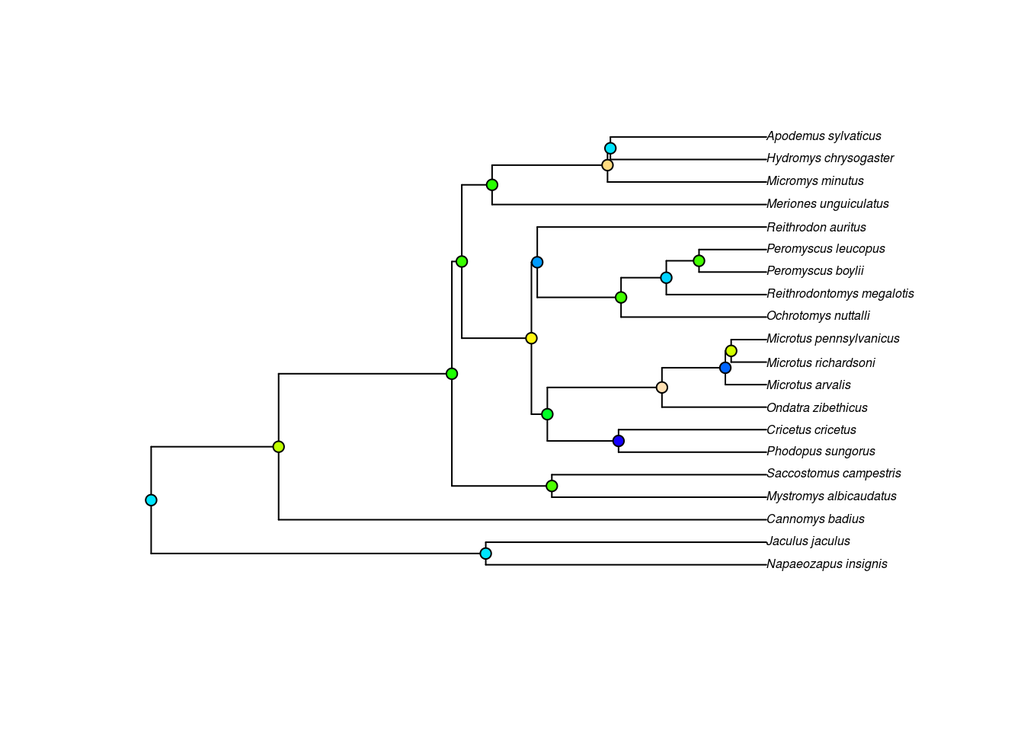

```r
picMass <- pic(dat$lnMass, tree)
plot(tree, cex=0.5)
nodelabels(pch=21, bg=topo.colors(100)[round((picMass-min(picMass))/diff(range(picMass))*100,0)])
```

**Challenge:** Make the size of the points at the nodes also vary with the size of the contrast

Phytools’ scattergram can be useful for exploring correlations between traits across the phylogeny:

```r
fancyDat <- as.matrix(dat[,1:3])
rownames(fancyDat) <- tree$tip.label
fancyTree(tree, type="scattergram", X=fancyDat, fsize=0.3)
```

```
## Computing multidimensional phylogenetic scatterplot matrix...
```

[figure not shown]

## V. Simple analyses of traits

### Discrete trait models

We generally use “continuous-time Markov models” to model discrete traits on the phylogeny. These models are used to model transitions between discrete character states, whether they are the presence/absence of phenotypic trait or nucleotide a specific site. We can fit such a model to a trait and a phylogeny using the `fitDiscrete` function in in `geiger`.

```r
tdDiscrete <- filter(td, !is.na(desert))
trait <- setNames(tdDiscrete$dat$desert, tdDiscrete$phy$tip.label)+1
mER <- fitDiscrete(tdDiscrete$phy, trait, model="ER")
mARD <- fitDiscrete(tdDiscrete$phy, trait, model="ARD")
mER
```

```
## GEIGER-fitted comparative model of discrete data
##  fitted Q matrix:
##                1          2
##     1 -0.0063744  0.0063744
##     2  0.0063744 -0.0063744
##
##  model summary:
##  log-likelihood = -6.121034
##  AIC = 14.242068
##  AICc = 14.464290
##  free parameters = 1
##
## Convergence diagnostics:
##  optimization iterations = 100
##  failed iterations = 0
##  frequency of best fit = 1.00
##
##  object summary:
##  'lik' -- likelihood function
##  'bnd' -- bounds for likelihood search
##  'res' -- optimization iteration summary
##  'opt' -- maximum likelihood parameter estimates
```

```r
mARD
```

```
## GEIGER-fitted comparative model of discrete data
##  fitted Q matrix:
##                  1            2
##     1 -0.008065052  0.008065052
##     2  0.046136016 -0.046136016
##
##  model summary:
##  log-likelihood = -6.062280
##  AIC = 16.124560
##  AICc = 16.830442
##  free parameters = 2
##
## Convergence diagnostics:
##  optimization iterations = 100
##  failed iterations = 0
##  frequency of best fit = 0.29
##
##  object summary:
##  'lik' -- likelihood function
##  'bnd' -- bounds for likelihood search
##  'res' -- optimization iteration summary
##  'opt' -- maximum likelihood parameter estimates
```

### Continuous trait models

For continuous traits, we generally use “Gaussian models” that result in multivariate normal distributions. The most basic and familiar of these is Brownian motion. We can fit a Brownian motion model using the function `fitContinuous` from the `geiger` package.

```r
trait <- setNames(dat$lnMass, tree$tip.label)
mBM <- fitContinuous(tree, trait, model="BM")
mBM
```

```
## GEIGER-fitted comparative model of continuous data
##  fitted 'BM' model parameters:
##  sigsq = 0.129322
##  z0 = 4.318866
##
##  model summary:
##  log-likelihood = -37.496496
##  AIC = 78.992992
##  AICc = 79.698874
##  free parameters = 2
##
## Convergence diagnostics:
##  optimization iterations = 100
##  failed iterations = 0
##  frequency of best fit = 1.00
##
##  object summary:
##  'lik' -- likelihood function
##  'bnd' -- bounds for likelihood search
##  'res' -- optimization iteration summary
##  'opt' -- maximum likelihood parameter estimates
```

An more general model than the Brownian motion model is the Ornstein-Uhlenbeck model, which has one additional parameter describing the central tendency of traits to evolve toward an intermediate optimum (think of a rubber band pulling back towards an optimum trait value).

```r
mOU <- fitContinuous(tree, trait, model="OU")
mBM
```

```
## GEIGER-fitted comparative model of continuous data
##  fitted 'BM' model parameters:
##  sigsq = 0.129322
##  z0 = 4.318866
##
##  model summary:
##  log-likelihood = -37.496496
##  AIC = 78.992992
##  AICc = 79.698874
##  free parameters = 2
##
## Convergence diagnostics:
##  optimization iterations = 100
##  failed iterations = 0
##  frequency of best fit = 1.00
##
##  object summary:
##  'lik' -- likelihood function
##  'bnd' -- bounds for likelihood search
##  'res' -- optimization iteration summary
##  'opt' -- maximum likelihood parameter estimates
```

Another model is one in which the rate of evolution is initially rapid, but slows over time. This is called the early-burst model (EB). Let’s fit all models simultaneously using first 1) a loop and then 2) the lapply function. This time, we’ll use the BMR data instead of the mass data:

```r
trait <- setNames(dat$lnBMR, tree$tip.label)
models <- c("BM", "OU", "EB")
mFits <- list()
for(i in 1:length(models)){
  mFits[[i]] <- fitContinuous(tree, trait, model=models[i])
}
#Above can also be accomplished by using lapply:
mFits <- lapply(1:length(models), function(i) fitContinuous(tree, trait, model=models[i]))
```

Model selection can be conducted by comparing AIC values:

```r
aiccs <- lapply(mFits, function(x) x$opt$aicc)
names(aiccs) <- models
aiccs
```

```
## $BM
## [1] 80.77013
##
## $OU
## [1] 75.92073
##
## $EB
## [1] 83.56433
```

### Phylogenetic signal

Phylogenetic signal is covariation in traits between related species in the phylogeny. There are several methods for testing for phylogenetic signal. Remember to be cautious drawing strong conclusions about biological processes from a simple summary statistic such as phylogenetic signal. However, in general you can think of two sides of the continuum– Strong phylogenetic signal indicates that closely related species are more similar to each other than other species. Whereas weak phylogenetic signal indicates that the variation among species is essentially random with respect to phylogeny.

#### Pagel’s Lambda test

Pagel’s lambda test compares the fit of a BM model on the original tree to a BM model with a lambda rescaled tree. A lambda equal to 0 produces the following tree:

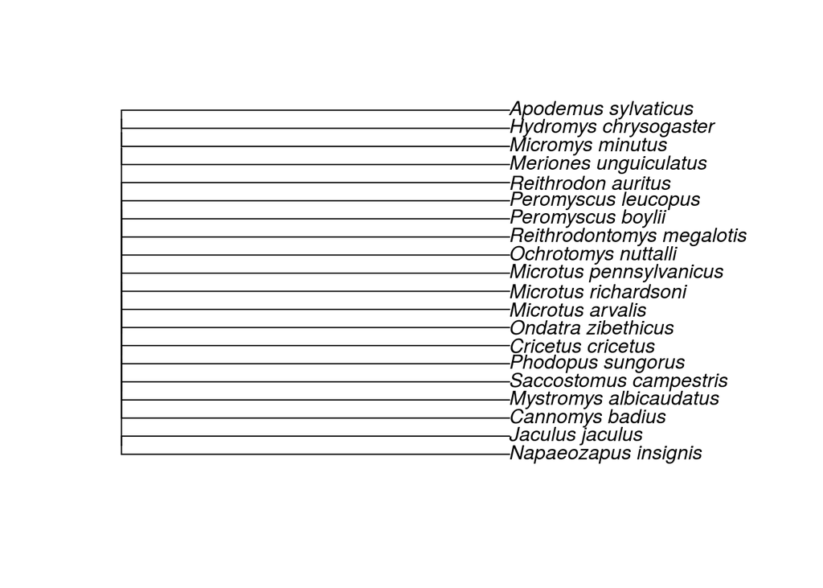

```r
l0tree <- rescale(tree, "lambda", 0)
plot(l0tree)
```

A lambda equal to 1 is the original tree. We can also estimate the value of lambda that best explains the data.

```r
trait <- setNames(dat$lnMass, tree$tip.label) #Make a named data vector
m1 <- fitContinuous(l0tree, trait, model = "BM") #Fit the BM model to the lambda=0 tree
m2 <- fitContinuous(tree, trait, model = "lambda") #Fit the BM model while simultaneously estimating lambda
lnlValues <- c(m1$opt$lnL, m2$opt$lnL) #Create a vector of the resulting log-likelihood values
names(lnlValues) <- c("Lambda fixed at zero", "Lambda estimated") #Give the vector names
lambdaValue <- m2$opt$lambda #Pull out the estimated lambda value
chisqTestStat <- 2 * (m2$opt$lnL - m1$opt$lnL) #Calculate the Chi square test statistic
chisqPVal <- pchisq(chisqTestStat, 1, lower.tail = F) #Calculate the probability of the Chi-square statistic under the null
aiccScores <- c(m1$opt$aicc, m2$opt$aicc) #Pull out the aicc values
names(aiccScores) <- c("Lambda fixed at zero", "Lambda estimated")#Name them
res <- list(lnlValues = lnlValues, chisqTestStat = chisqTestStat,
            chisqPVal = chisqPVal, aiccScores = aiccScores, lambdaValue = lambdaValue) #Create a list of results
print(res) #Print out the results
```

```
## $lnlValues
## Lambda fixed at zero     Lambda estimated
##            -34.21951            -34.21951
##
## $chisqTestStat
## [1] 1.421085e-14
##
## $chisqPVal
## [1] 0.9999999
##
## $aiccScores
## Lambda fixed at zero     Lambda estimated
##             73.14490             75.93902
##
## $lambdaValue
## [1] 1.447518e-212
```

Make this into a function:

```r
physigLambda <- function(tree, trait){
  m1 <- fitContinuous(l0tree, trait, model = "BM")
  m2 <- fitContinuous(tree, trait, model = "lambda")
  lnlValues <- c(m1$opt$lnL, m2$opt$lnL)
  names(lnlValues) <- c("Lambda fixed at zero", "Lambda estimated")
  lambdaValue <- m2$opt$lambda
  chisqTestStat <- 2 * (m2$opt$lnL - m1$opt$lnL)
  chisqPVal <- pchisq(chisqTestStat, 1, lower.tail = F)
  aiccScores <- c(m1$opt$aicc, m2$opt$aicc)
  names(aiccScores) <- c("Lambda fixed at zero", "Lambda estimated")
  res <- list(lnlValues = lnlValues, chisqTestStat = chisqTestStat,
              chisqPVal = chisqPVal, aiccScores = aiccScores, lambdaValue = lambdaValue)
  return(res)
}

physigLambda(tree, setNames(dat$lnBMR, tree$tip.label))
```

```
## $lnlValues
## Lambda fixed at zero     Lambda estimated
##             -34.4654             -34.4654
##
## $chisqTestStat
## [1] 0
##
## $chisqPVal
## [1] 1
##
## $aiccScores
## Lambda fixed at zero     Lambda estimated
##             73.63669             76.43080
##
## $lambdaValue
## [1] 1.498792e-217
```

**Challenge:** How could you design a version that measures phylogenetic signal for a discrete trait that also uses a lambda transformation?

Note that some have criticized Pagel’s Lambda for being hard to interpret, sensitive to the taxa included and be absent an evolutionary model. A particularly nice explanation can be found [here](http://www.carlboettiger.info/2013/10/11/is-it-time-to-retire-pagels-lambda.html)

### Phylogenetic half-life

Phylogenetic half-life is a measure of phylogenetic signal proposed by Hansen et al. (2008) which relies on an Ornstein-Uhlenbeck model of evolution. We will talk more about OU models later for studying adaptive evolution. For interpreting in terms of phylogenetic signal, it helps to consider in terms of the covariance between traits expected under a given phylogeny. For Brownian motion the expected covariance is simply equal to the branch length of the tree.

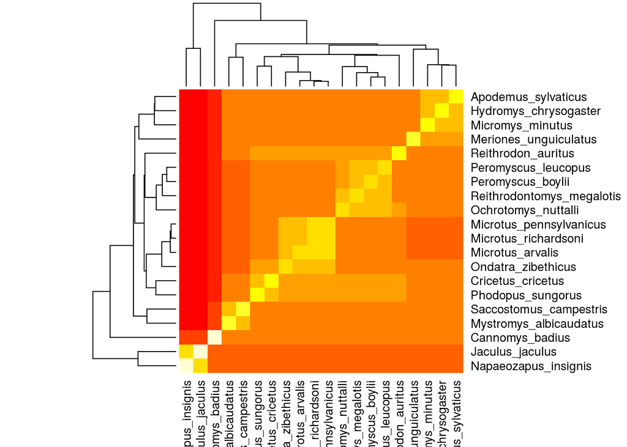

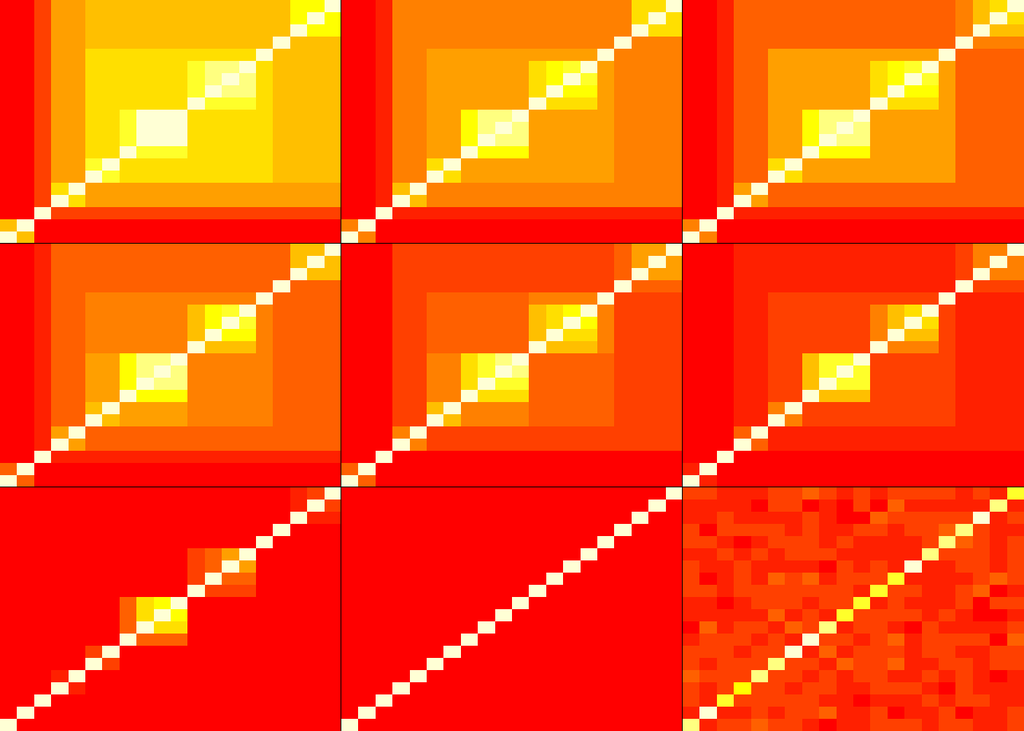

```r
{
vcvBM <- vcvPhylo(tree, anc.nodes=FALSE)
dend <- as.dendrogram(as.hclust(tree))
heatmap(vcvBM, Rowv = dend, Colv = dend)

par(mfrow=c(3,3), mar=c(0,0,0,0))
image(vcvBM, xaxt="n", yaxt="n")
halflifeseq <- seq(50, 1, length.out=7)
for(i in 1:7){
  vcv <- vcvPhylo(rescale(tree, model="OU", log(2)/halflifeseq[i]), anc.nodes=FALSE)
  image(vcv, xaxt="n", yaxt="n")
}
iidData <- matrix(rnorm(200*length(tree$tip.label), mean(dat$lnMass), 2), ncol=length(tree$tip.label))
vcv <- var(iidData)
image(vcv, xaxt="n", yaxt="n")
}
```

```r
mOU <- fitContinuous(tree, setNames(dat$lnMass, tree$tip.label), model="OU")
str(mOU)
```

[output not shown]

[output cut: 167 more lines]

[output not shown]

```r
halflife <- log(2)/mOU$opt$alpha
halflife/max(branching.times(tree))
```

```
## [1] 0.1113411
```

A (very) rough guide for interpreting: half-life/tree length = 0-0.1 -> Very strong; = 0.1-0.3 -> Strong; 0.3-0.5 -> Moderate; 0.5-1 -> Weak; >1 Probably not distinct from BM.

#### PGLS - Determining relationship between traits

Phylogenetic generalized least squares is a method for assessing whether phenotypic traits are related to one another. This is a general method of the original independent contrasts methods proposed by Felsenstein (1985).

```r
corBM <- corBrownian(1, phy=tree)
corOU <- corMartins(0.001, phy=tree)

pglsBM <- gls(lnBMR~lnMass, correlation=corBM, data=dat)
pglsOU <- gls(lnBMR~lnMass, correlation=corOU, data=dat)
summary(pglsBM)
```

```
## Generalized least squares fit by REML
##   Model: lnBMR ~ lnMass
##   Data: dat
##        AIC      BIC    logLik
##   21.58914 24.26026 -7.794572
##
## Correlation Structure: corBrownian
##  Formula: ~1
##  Parameter estimate(s):
## numeric(0)
##
## Coefficients:
##                  Value Std.Error   t-value p-value
## (Intercept) -0.0219068 0.3424398 -0.063973  0.9497
## lnMass       1.0076317 0.0469641 21.455360  0.0000
##
##  Correlation:
##        (Intr)
## lnMass -0.592
##
## Standardized residuals:
##         Min          Q1         Med          Q3         Max
## -0.66411491 -0.31464492  0.04474136  0.33548742  0.65238288
##
## Residual standard error: 0.5143211
## Degrees of freedom: 20 total; 18 residual
```

```r
summary(pglsOU)
```

```
## Generalized least squares fit by REML
##   Model: lnBMR ~ lnMass
##   Data: dat
##        AIC      BIC    logLik
##   7.434208 10.99569 0.2828961
##
## Correlation Structure: corMartins
##  Formula: ~1
##  Parameter estimate(s):
##    alpha
## 4.745379
##
## Coefficients:
##                 Value  Std.Error  t-value p-value
## (Intercept) 0.0144562 0.14145032  0.10220  0.9197
## lnMass      1.0025634 0.03313345 30.25834  0.0000
##
##  Correlation:
##        (Intr)
## lnMass -0.95
##
## Standardized residuals:
##         Min          Q1         Med          Q3         Max
## -1.74732467 -0.92373554  0.03952009  0.76765023  1.67215578
##
## Residual standard error: 0.198432
## Degrees of freedom: 20 total; 18 residual
```

## Questions & exercises:

1. If you have phylogenetic signal in the trait of interest, that means you MUST USE a phylogenetic regression method (e.g. PGLS, PICs) to analyze the trait. Explain (Hint: Look up the assumptions of Ordinary Least Squares regression).
2. You conduct model selection using fitContinuous and find that the OU model is a better fit to trait evolution over BM. You should prefer an OU correlation structure for any PGLS model you fit. Why or why not?
3. Each of the following lines of code produces an error. Fix the error to accomplish the task requested.
1. Fit a BM model using fitContinuous

```r
ex3a <- readRDS("../data/ex3a.rds")
phy <- ex3a$tree
trait <- ex3a$dat
try(fitContinuous(phy, trait, model="BM"))
```

2. Plot a phenogram of the data

```r
ex3b <- readRDS("../data/ex3b.rds")
phy <- ex3b$tree
trait <- ex3b$dat
try(phenogram(phy, trait[,1], spread.labels=FALSE))
```

4. Below we have a dataset of 23 species of Icterus (New World Orioles) and a posterior distribution of phylogenies from www.birdtree.org based on genetic sequence data (Hackett backbone). Fit a Brownian motion model to each tree for Tarsus length, save all the results as a list, and extract the estimate of the sigma^2 parameter. Plot a histogram of that parameter.

```r
icterus <-  read.table("../data/icterus.dat", header=TRUE, sep="\t")
icterus.trees <- read.nexus("../data/icterus.tre")

icterus.trees
```

```
## 100 phylogenetic trees
```

```r
BMfitter <- function(i){
  ## Fill this in with code to A) match tree and data B) select Tarsus as the dataset C) perform a fitContinuous fit
  ## and D) return the fitted object
}
```

Use a loop or an lapply call to call the `BMfitter` function for all values of i from 1 to 100

Use sapply to extract all the estimates of the parameter `sigsq`

Plot the resulting vector of sigma^2 estimates.